# ABET Assessment Results for AY 2020-21

## Summary

| Outcome | % Excelled | % Mastered | % Partially Mastered | % Below Expectations | #Student Assessments |
| --- | --- | --- | --- | --- | --- |
| (1) | NA | NA | NA | NA | 0 |
| (2) | 58 | 39 | 3 | 0 | 41 |
| (3) | 67 | 33 | 0 | 0 | 26 |
| (4) | NA | NA | NA | NA | 0 |
| (5) | 41 | 34 | 25 | 0 | 42 |
| (6) | NA | NA | NA | NA | 0 |

Considering Excelled and Mastered to “Satisfy” each student outcome, we can look at historical trends.

| Outcome | %Satisfied 2014-15 | %Satisfied 2015-16 | %Satisfied 2016-17 | %Satisfied 2018-19 | %Satisfied 2019-20 | %Satisfied 2020-21 | Last Year Change |
| --- | --- | --- | --- | --- | --- | --- | --- |
| (1) | 83 | 79 | 73 | 60 | NA | NA | NA |
| (2) | 79 | 80 | 93 | 100 | NA | 97 | -3 |
| (3) | 89 | 96 | 76 | 100 | NA | 100 | 0 |
| (4) | 100 | 100 | 98 | 86 | 91 | NA | NA |
| (5) | 83 | 77 | 96 | 100 | NA | 75 | -25 |
| (6) | 94 | 62 | 51 | 53 | NA | NA | NA |

The following graphs show the history of the outcomes (1) through (6), using data from the old outcomes (a)-(k) for prior years.

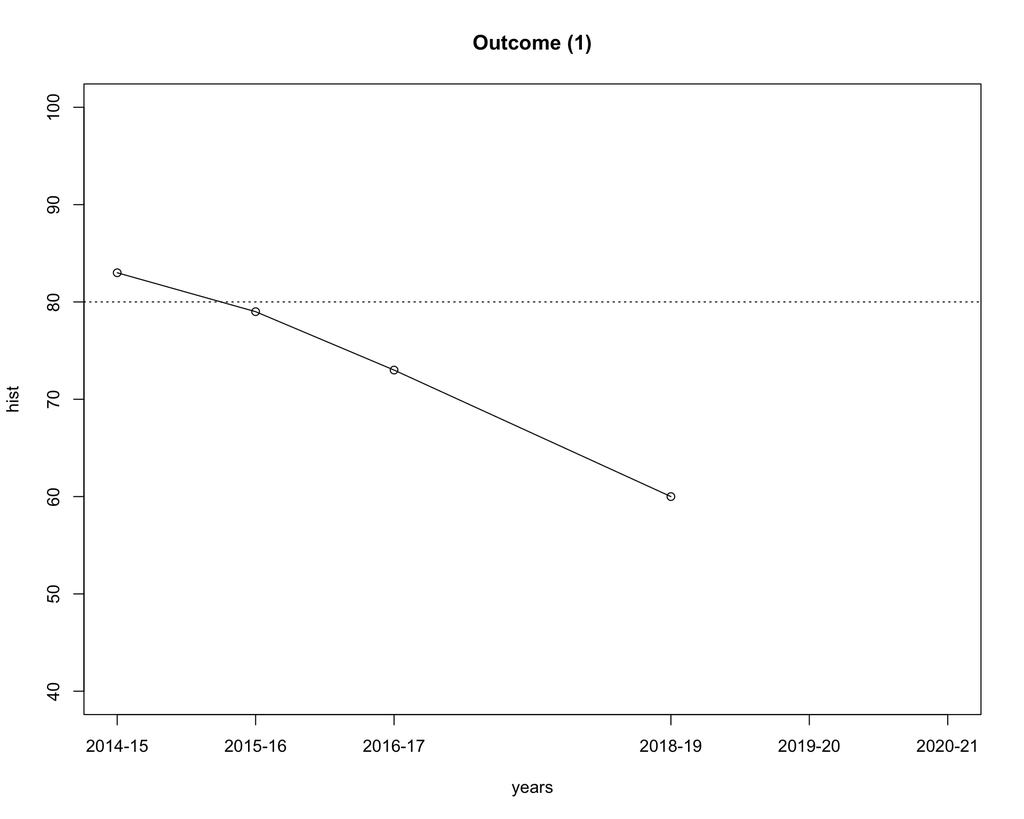

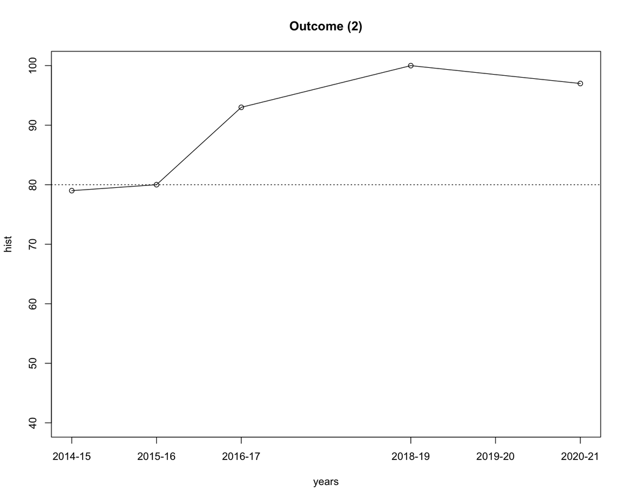

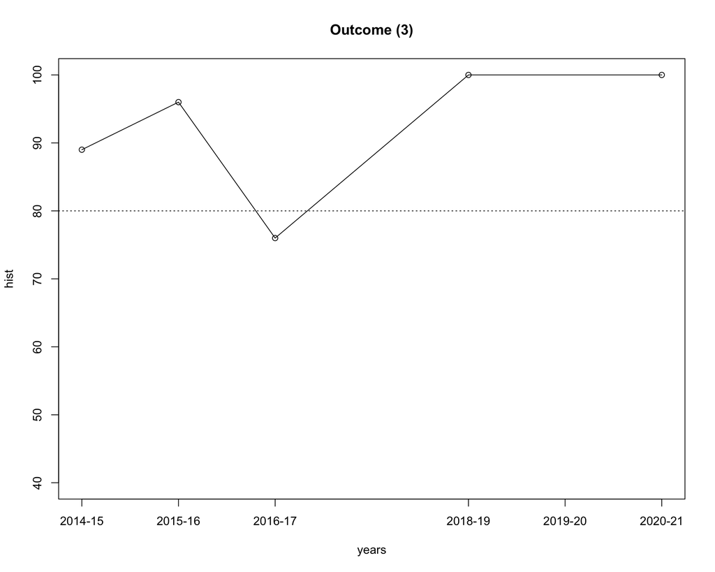

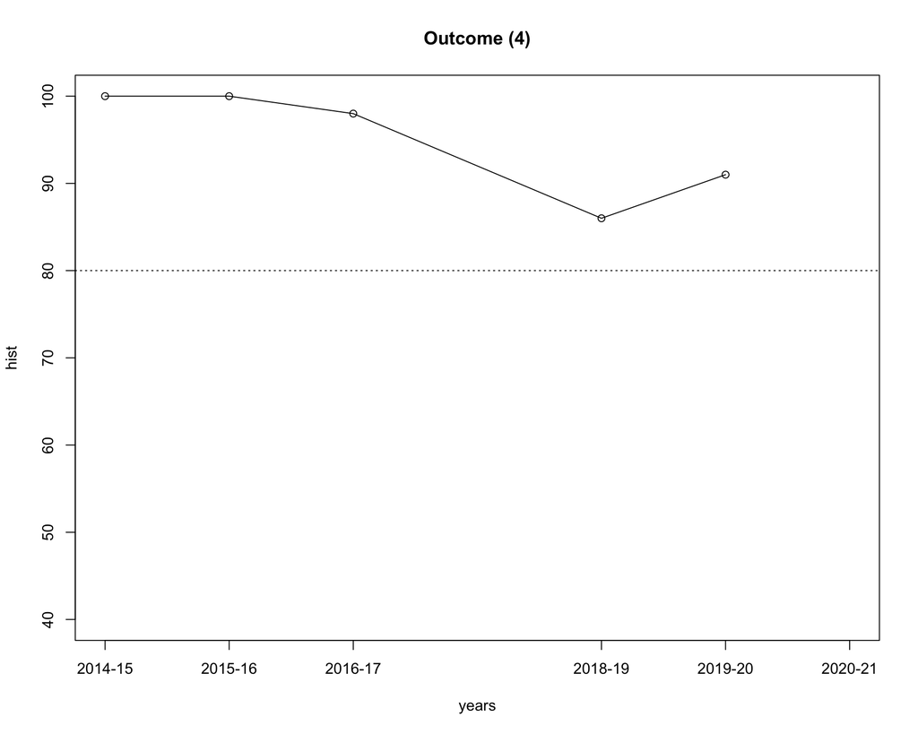

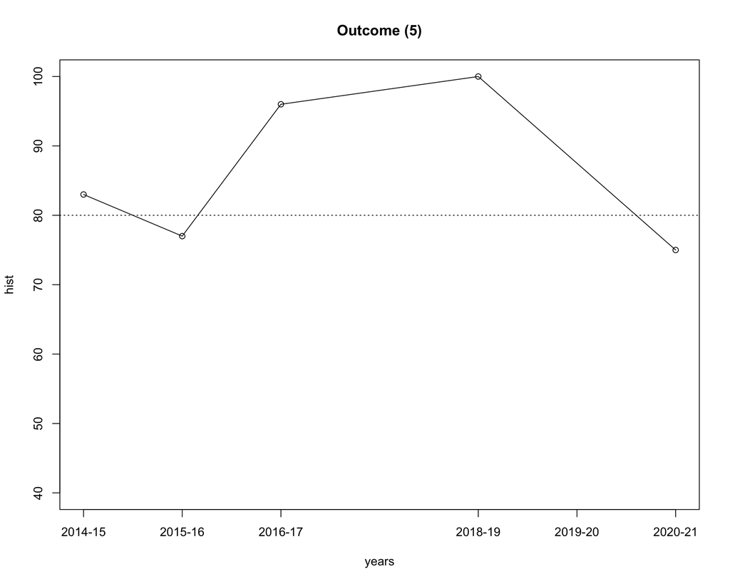

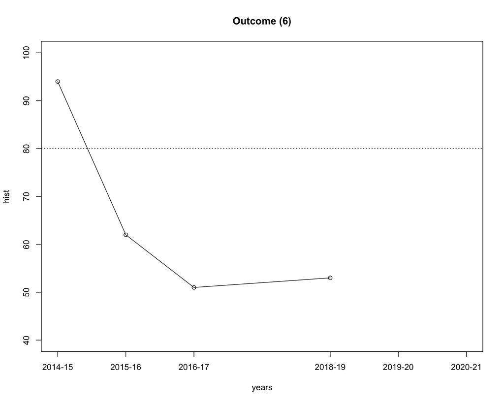

More details of student assessment can be seen by considering the assessment of individual PKIs.

[output not shown]

## Assessment Data

### COSC 3020: Algorithms & Data Structures, Lars Kotthoff MISSING

| Core Course | Assessed |
| --- | --- |
| COSC 3020: Algorithms & Data Structures | Every other year, starting 2016-17 |

```
Performance Indicator (a.4): Calculate the sum of arithmetic series
                             that arise in computing applications
```

```
Performance Indicator (a.5): Calculate the sum of geometric series
                             that arise in computing applications
```

```
Performance Indicator (a.6) :  Use calculus to find the asymptotic limit of functions
```

```
Performance Indicator (b.1) :  Identify key components and algorithms necessary for a solution

Assignment 3: Implement two algorithms for solving the traveling salesman
problem and compare them.

34 students assessed.

10 students excelled.
9 students mastered.
4 students partially mastered.
11 students were below expectations.
```

```
Performance Indicator (b.2) :  Analyze at two or more proposed solutions to a given problem and select the best solution for the given problem

Assignment 3: Implement two algorithms for solving the traveling salesman
problem and compare them.

34 students assessed.

10 students excelled.
9 students mastered.
4 students partially mastered.
11 students were below expectations.
```

```
Performance Indicator (j.1) :  Analyze the asymptotic cost of divide-and-conquer algorithms

Question 3 in assignment 2: Implement an iterative and in-place version of merge
sort and analyze its complexity.

31 students assessed.

4 students excelled.
5 students mastered.
14 students partially mastered.
8 students were below expectations.
```

```
Performance Indicator (j.2) :  Analyze the asymptotic cost of recursive algorithms

Question 3 in the midterm: Give Theta-bounds for three recurrence
relations.

33 students assessed.

13 students excelled.
8 students mastered.
12 students partially mastered.
0 students were below expectations.
```

```
Performance Indicator (j.3): Analyze the asymptotic cost of basic graph algorithms

Lab 7: Implement the Floyd-Warshall algorithm and analyze its complexity.

34 students assessed.

24 students excelled.
8 students mastered.
2 students were below expectations.
```

```
Performance Indicator (j.4):  Describe the impact of techniques such as caching
and dynamic programming on the performance of algorithms

Question 5 in final: Implement a dynamic programming solution to
compute the Liouville number.

33 students assessed.

3 students excelled.
2 students mastered.
20 students partially mastered.
8 students were below expectations.
```

```
Performance Indicator (j.5):  Understand the difference between polynomial
and exponential complexity

Assignment 3: Implement two algorithms for solving the traveling salesman
problem (one complete, exponential complexity, one approximate, polynomial
complexity) and compare them.

34 students assessed.

10 students excelled.
9 students mastered.
4 students partially mastered.
11 students were below expectations.
```

### COSC 4950/5: Senior Design I & II, Mike Borowczak

| Core Course | Assessed |
| --- | --- |
| COSC 4950: Senior Design I | Every other year, starting 2017-18 |
| COSC 4955: Senior Design II | Every other year, starting 2017-18 |

This is the capstone course. Students work in groups ranging from 3 to 5, select a project, and create a software system to solve it. The students flesh out the project ideas, deciding on the important features and trying to come to terms with project risk. They decide what technology to use, and they proceed to implementation. They also document their decisions by writing use cases, or other tools as appropriate (e.g., story boards for projects that choose to write games).

Classtime is devoted to group work and presentations that updated the instructor and the other teams on the status of the project. They also create a poster presentation of their project and do a final presentation to a wide audience. The class presentations, poster, and final presentations are the main tools used for assessment.

```
Performance Indicator (2.1): Identify constraints on the design problem

Does the capstone Project Design Document contain details on constraint (e.g. limitations, and feasiblity)

34 students were assessed.

25 students excelled.
9 students mastered.
0 students partially mastered.
0 students were below expectations.
```

```
Performance Indicator (2.2): Establish acceptance criteria for a solution

Does the capstone Project Design Document contain acceptence criteria (e.g. gated design/acceptance criteria)?

34 students were assessed.

8 students excelled.
21 students mastered.
5 students partially mastered.
0 students were below expectations.
```

```
Performance Indicator (2.3): Design the selected solution for a given problem

Mid-capstone presentation and github respositories contain evidence of design

34 students were assessed.

22 students excelled.
12 students mastered.
0 students partially mastered.
0 students were below expectations.
```

```
Performance Indicator (2.4): Implement the designed solution for a given problem

Capstone presentation and github respositories contain evidence of deliverables

34 students were assessed.

25 students excelled.
9 students mastered.
0 students partially mastered.
0 students were below expectations.
```

```
Performance Indicator (2.5): Evaluate the implemented solution

Mid-capstone presentation: Pathforward,  Evaluation of other designs

34 students were assessed.

16 students excelled.
13 students mastered.
5 students partially mastered.
0 students were below expectations.
```

```
Performance Indicator (5.1): Listen to other team members

End of capstone team reflection.

34 students were assessed.

22 students excelled.
8 students mastered.
4 students partially mastered.
0 students were below expectations.
```

```
Performance Indicator (5.2): Actively discuss team projects, objectives, or challenges with other team members

Actively discuss team projects, objectives, or challenges with other team members

34 students were assessed.

30 students excelled.
4 students mastered.
0 students partially mastered.
0 students were below expectations.
```

```
Performance Indicator (5.3): Fulfill team duties on time

Fulfill team duties on time

34 students were assessed.

18 students excelled.
16 students mastered.
0 students partially mastered.
0 students were below expectations.
```

```
Performance Indicator (5.4): Share in the work of the team

Status Updates; Git Tracking (does statement of responsibilities align to actual work performed)

34 students were assessed.

30 students excelled.
4 students mastered.
0 students partially mastered.
0 students were below expectations.
```

```
Performance Indicator (5.5): Research and gather information

Capstone Project Design Document

34 students were assessed.

0 students excelled.
34 students mastered.
0 students partially mastered.
0 students were below expectations.
```

```
Performance Indicator (3.1): Write technical reports

Is the Capstone Project Design Document written for a technical audience?

34 students were assessed.

0 students excelled.
34 students mastered.
0 students partially mastered.
0 students were below expectations.
```

```
Performance Indicator (3.2): Present technical material to technical peers

Capstone presentation survey tool: did peers understand the presentation?

34 students were assessed.

34 students excelled.
0 students mastered.
0 students partially mastered.
0 students were below expectations.
```

```
Performance Indicator (3.3): Present technical material to non-technical visitors

Capstone presentation survey tool: did non-technical visitors understand the presentation?

34 students were assessed.

34 students excelled.
0 students mastered.
0 students partially mastered.
0 students were below expectations.
```